# Water Table EDA

Zach Turner

September 10, 2016

This notebook will be used to explore the Water Table dataset.

### Training Data

The training data comes in two parts, one is the independent variables and the second is the dependent variable. I’ll combine those together right away before doing anything else.

```r
library(dplyr)
library(ggplot2)
library(cowplot)
library(reshape2)
library(scales)
library(knitr)
setwd("~/Git/Contests/DrivenData/WaterTable")
training1 <- read.csv("training.csv",sep=",")
training2 <- read.csv("training_labels.csv",sep=",")
training <- inner_join(training1,training2,by="id")

# Make training labels shorter
levels(training$status_group) <- c("F","R","NF")

# Make factors character
training[sapply(training,class)=="factor"] <- lapply(training[sapply(training,class)=="factor"],as.character)

rm(training1,training2)
```

### Basics

First I want to see a few things about the dataset as a whole, and then I’ll break a bit deeper into looking at the numeric/character variables.

```r
dim(training)
```

```
## [1] 59400    41
```

```r
# Return any variables with missing values
colnames(training)[lapply(training,function(x) mean(is.na(x)))>0]
```

```
## character(0)
```

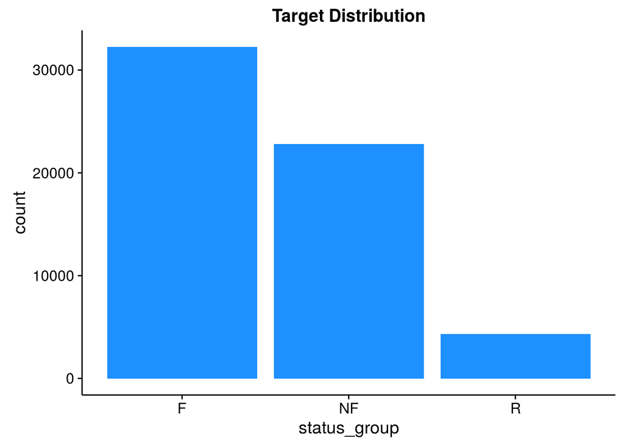

```r
# Target
ggplot(data=training) + geom_bar(aes(x=status_group,y=..count..),fill="dodgerblue") + ggtitle("Target Distribution")
```

So I don’t have any missing data, which is great. I can also see that most of the pumps are either functional or not functional. Pumps that need repair are more rare and will probably be a bit tougher to identify.

```r
table(sapply(training,class))
```

```
##
## character   integer   numeric
##        31         7         3
```

We have 31 factor variables (including the response), and then 10 numeric predictors.

### Numeric Data

Since I don’t have too many numeric variables, it won’t be too tough to explore them individually. I want to examine their histograms and then their correlations with the target.

```r
numvars <- colnames(training)[sapply(training,class)!="character"]
numvars
```

```
##  [1] "id"                "amount_tsh"        "gps_height"
##  [4] "longitude"         "latitude"          "num_private"
##  [7] "region_code"       "district_code"     "population"
## [10] "construction_year"
```

These region_code and district_code variables aren’t truly continuous so I want to change those data types and worry about them later.

```r
training[c("region_code","district_code")] <- lapply(training[c("region_code","district_code")],as.character)
```

#### Histograms

I want to examine some histograms broken apart by their target group to see how the distributions may differ.

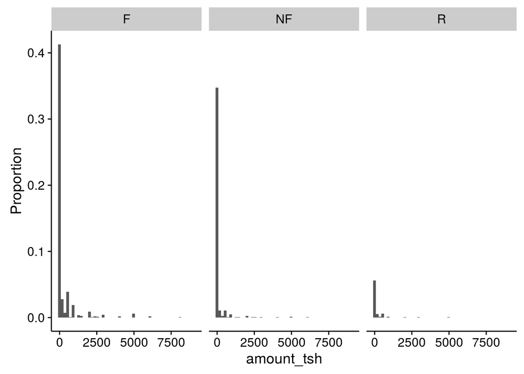

```r
training %>% filter(amount_tsh < 10000) %>% ggplot(aes(x=amount_tsh)) + geom_histogram(aes(y=..count../sum(..count..)),bins=50) + facet_wrap(~status_group) + labs(ylab("Proportion"))
```

So across the board, amount_tsh is mostly 0. (Amount_tsh refers to the height of the water discharge location relative to the water in the tank)

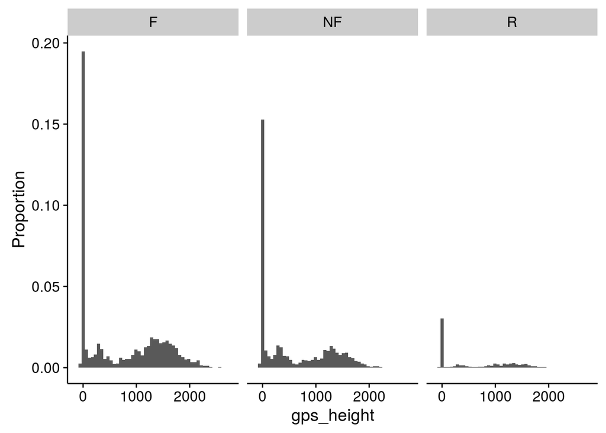

```r
training %>% ggplot(aes(x=gps_height)) + geom_histogram(aes(y=..count../sum(..count..)),bins=50) + facet_wrap(~status_group) + labs(ylab("Proportion"))
```

I also want to see if I can carve out any details from the latitude/longitude.

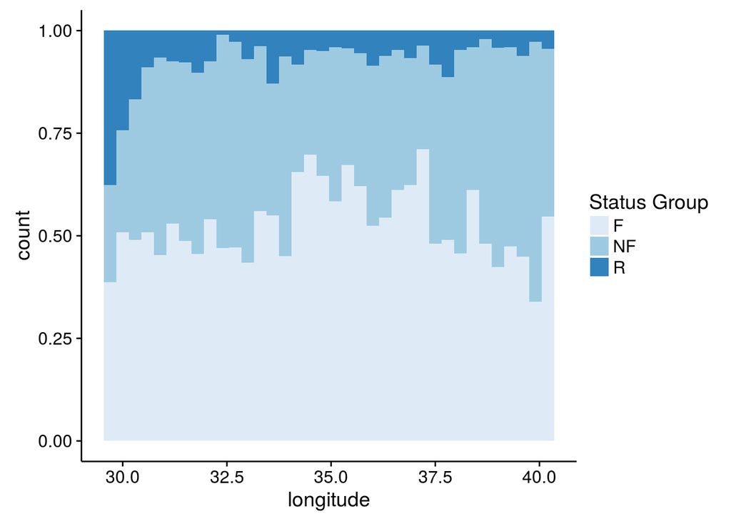

```r
training %>% filter(longitude>0) %>% ggplot(aes(x=longitude,fill=as.factor(status_group))) + geom_histogram(position="fill",binwidth=0.3) + scale_fill_brewer(palette="Blues") + labs(fill="Status Group")
```

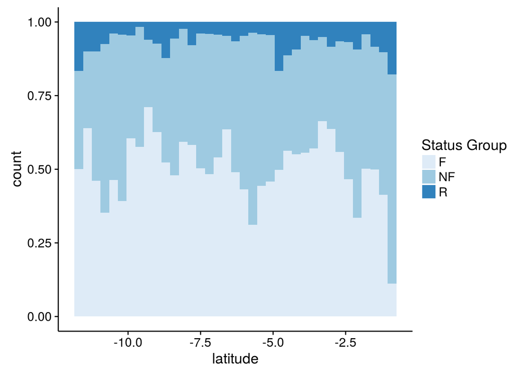

```r
training %>% filter(latitude < -1) %>% ggplot(aes(x=latitude,fill=as.factor(status_group))) + geom_histogram(position="fill",binwidth=0.3) + scale_fill_brewer(palette="Blues") + labs(fill="Status Group")
```

There appear to be some regions where the pumps are more functional. Probably the most interesting find is that longitudes near 30 tend to have more pumps that need repair – this may come in handy.

The vast majority of num_private is 0, so I want to split this out separately.

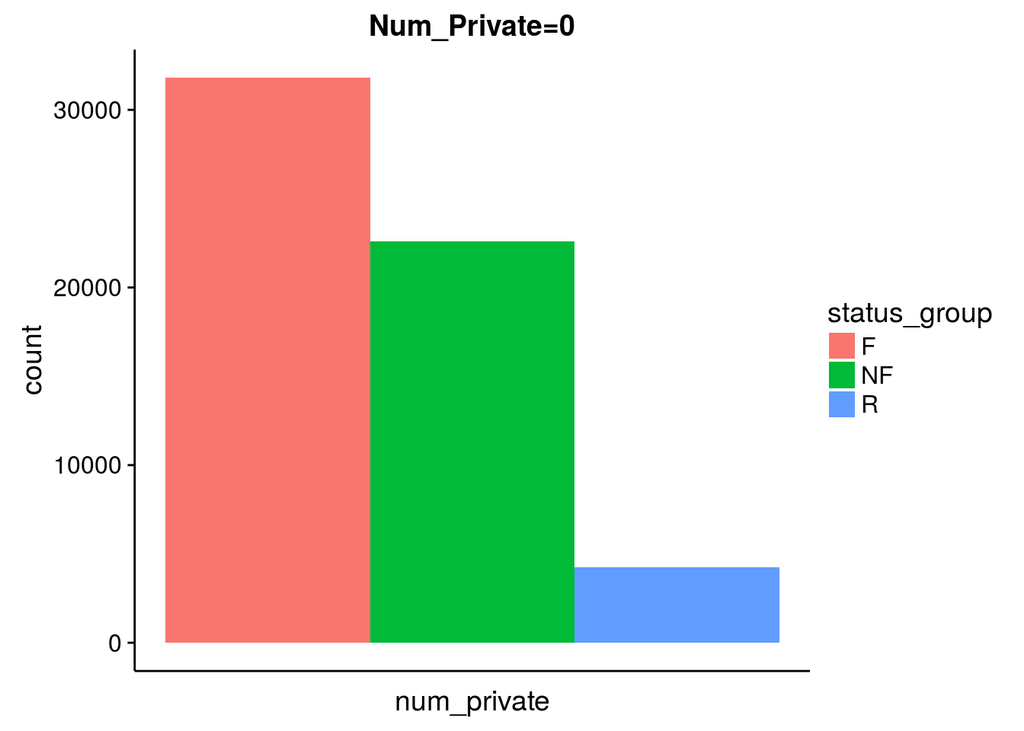

```r
training %>% filter(num_private==0) %>% ggplot() + geom_bar(aes(x=num_private,fill=status_group),position = "dodge") + theme(axis.ticks.x=element_blank(),axis.text.x=element_blank()) + ggtitle("Num_Private=0")
```

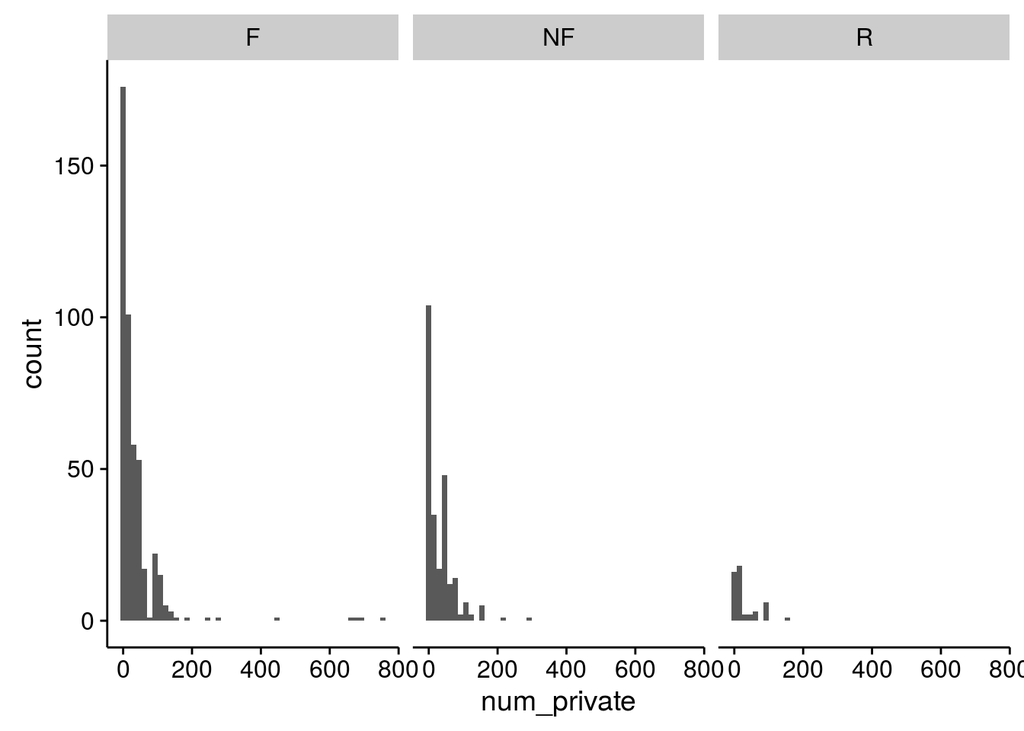

```r
training %>% filter(num_private !=0,num_private < 1000) %>% ggplot() + geom_histogram(aes(x=num_private),bins=50) + facet_wrap(~status_group)
```

This doesn’t really seem to tell us anything new.

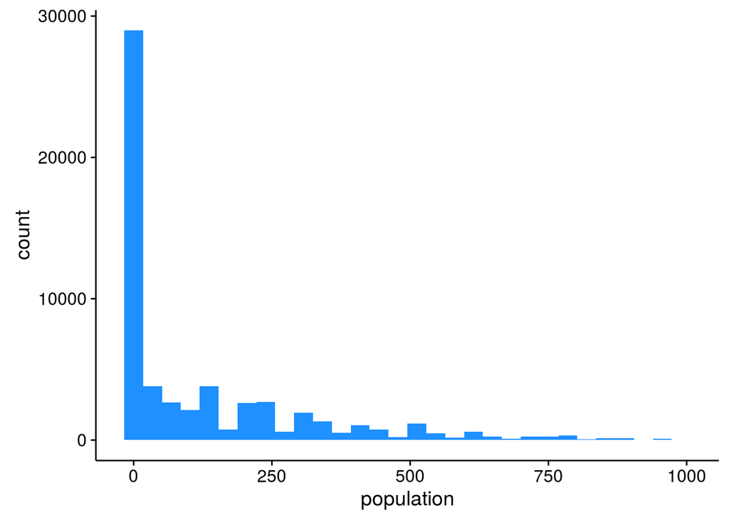

```r
training %>% filter(population < 1000) %>% ggplot() + geom_histogram(aes(population),fill="dodgerblue")
```

I would expect to see that the older pumps are failing more often.

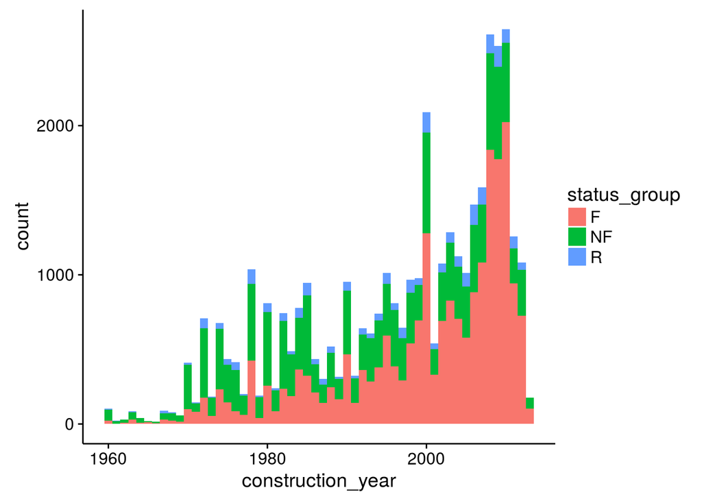

```r
training %>% filter(construction_year>0) %>% ggplot() + geom_histogram(aes(x=construction_year,fill=status_group),bins=54)
```

Ok, this is good. The older pumps tend to be less functional. However, we only have the ages for roughly half of the observations.

### Correlation

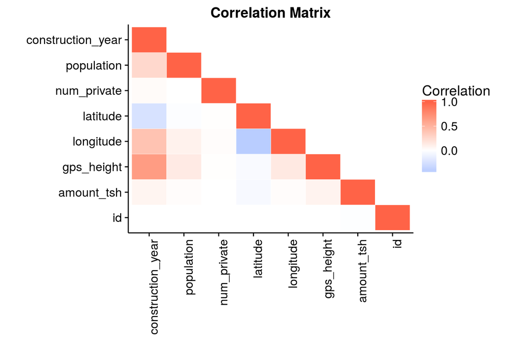

```r
numvars <- colnames(training)[sapply(training,class)!="character"]
matrix <- round(cor(training[,numvars]),2)
matrix[upper.tri(matrix)] <- NA
melted <- melt(matrix,na.rm=TRUE)
melted <- melted %>% arrange(Var1,Var2)
ggplot(data=melted) + geom_tile(aes(Var1,Var2,fill=value),color="white") + xlim(rev(levels(melted$Var1))) + scale_fill_gradient2("Correlation",low="dodgerblue",high="tomato") + labs(x="",y="",title="Correlation Matrix") + theme(axis.text.x=element_text(angle=90,hjust=1))
```

I find it somewhat interesting that there appears to be a correlation between construction year and the altitude of the well. However, this also appears to be related to the longitude. I imagine this is showing some type of regional spread in the well construction.

### Categorical Data

Before I dig any deeper I want to see what type of cardinality that I’m working with.

```r
char_vars <- colnames(training)[sapply(training,class)=="character"]
levels_df <- data.frame(Variable=char_vars,Levels=unname(sapply(training[char_vars],function(x) length(unique(x)))))
kable(levels_df)
```

| Variable | Levels |
| --- | --- |
| date_recorded | 356 |
| funder | 1898 |
| installer | 2146 |
| wpt_name | 37400 |
| basin | 9 |
| subvillage | 19288 |
| region | 21 |
| region_code | 27 |
| district_code | 20 |
| lga | 125 |
| ward | 2092 |
| public_meeting | 3 |
| recorded_by | 1 |
| scheme_management | 13 |
| scheme_name | 2697 |
| permit | 3 |
| extraction_type | 18 |
| extraction_type_group | 13 |
| extraction_type_class | 7 |
| management | 12 |
| management_group | 5 |
| payment | 7 |
| payment_type | 7 |
| water_quality | 8 |
| quality_group | 6 |
| quantity | 5 |
| quantity_group | 5 |
| source | 10 |
| source_type | 7 |
| source_class | 3 |
| waterpoint_type | 7 |
| waterpoint_type_group | 6 |
| status_group | 3 |

Some of these variables are going to cause issues because they have too many levels. My initial thoughts:

- `wpt_name`, `subvillage`, and `ward` have too many levels to work with, but I think there’s enough other geographical data to serve as proxies (basin, region, lat/long, etc.).
- `Installer` is likely important so I don’t want to give up on that variable just yet.
- `Scheme_management` is likely a suitable substitute for `scheme_name`.

### Notable categorical data

#### Date Recorded

If there’s no noticeable seasonal trends in the date_recorded variable I will just get rid of that as well.

```r
library(lubridate)
```

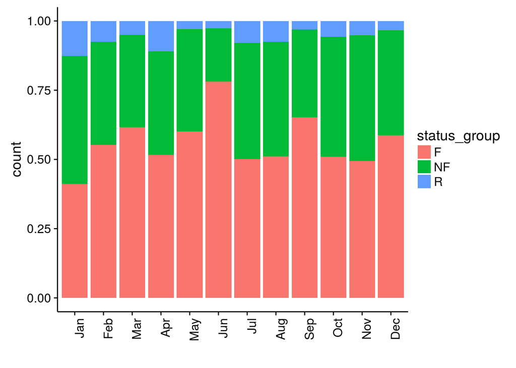

```r
training$date_recorded <- as.Date(training$date_recorded)
ggplot(data=training) + geom_bar(aes(x=month(date_recorded,label=TRUE),y=..count..,fill=status_group),position="fill") + labs(x="") + theme(axis.text.x=element_text(angle=90,hjust=1))
```

I’ll create a month recorded variable since there’s a couple of points where we have some spikes in non-functional pumps.

```r
training$month_recorded <- as.character(month(training$date_recorded,label=TRUE))
# Drop variables with too many levels (and recorded_by since it has 1 level)
training <- subset(training,select=-c(date_recorded,wpt_name,subvillage,ward,scheme_name,recorded_by))
```

#### Extraction Type Group

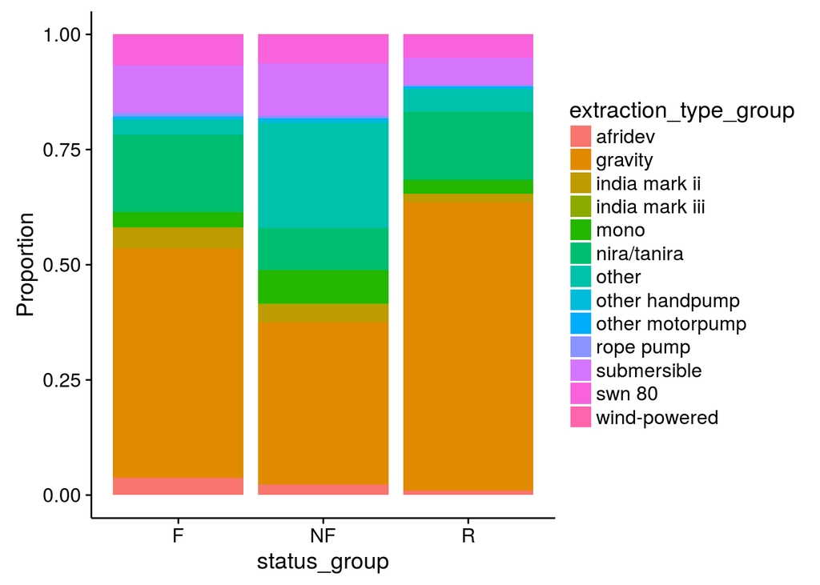

```r
ggplot(data=training) + geom_bar(aes(x=status_group,y=..count..,fill=extraction_type_group),position="fill") + labs(y=("Proportion"))
```

There’s noticeable fewer non-functional pumps with extraction_type_group “gravity”, and we see that groups labeled as “Other” are far more likely to be non-functional.

#### Payment Type

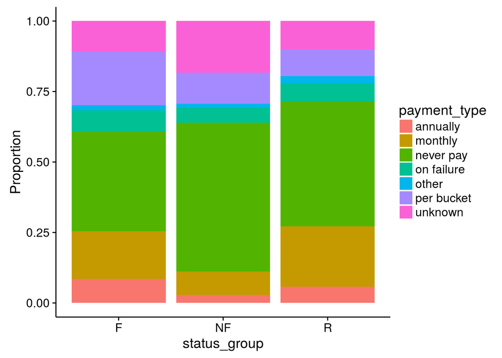

```r
ggplot(data=training) + geom_bar(aes(x=status_group,y=..count..,fill=payment_type),position="fill") + labs(y=("Proportion"))
```

If payment_type is “never” then the pump is more likely to be non functional (not too surprising I guess).

#### Water Quality / Quality Type

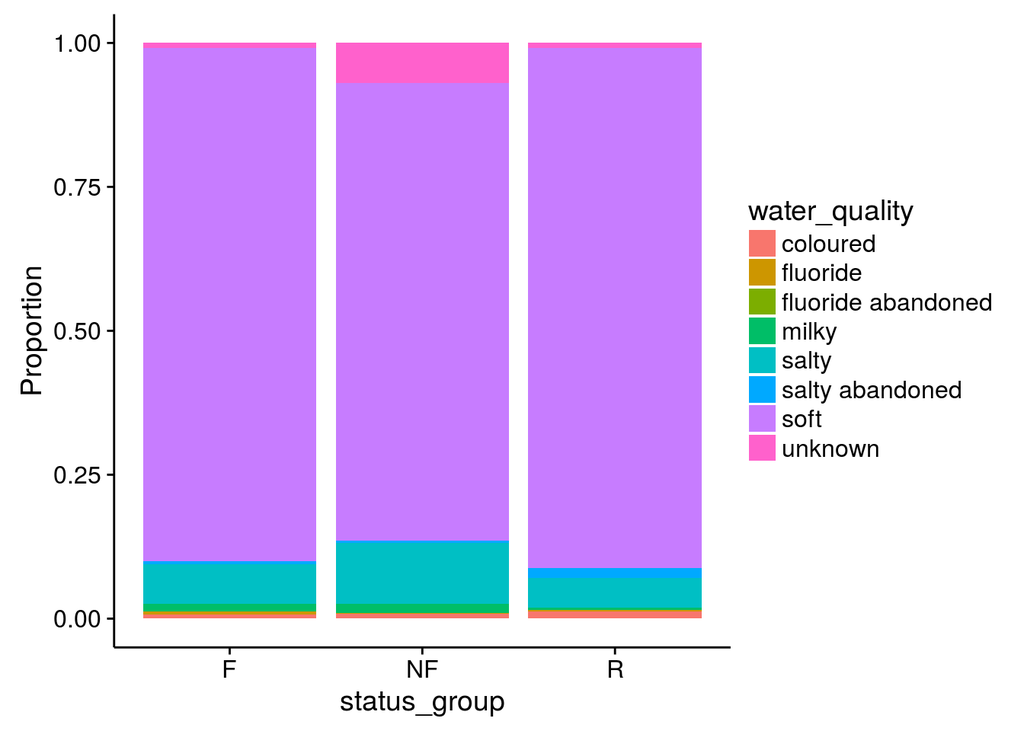

```r
ggplot(data=training) + geom_bar( aes(x=status_group,y=..count..,fill=water_quality),position="fill") + labs(y=("Proportion"))
```

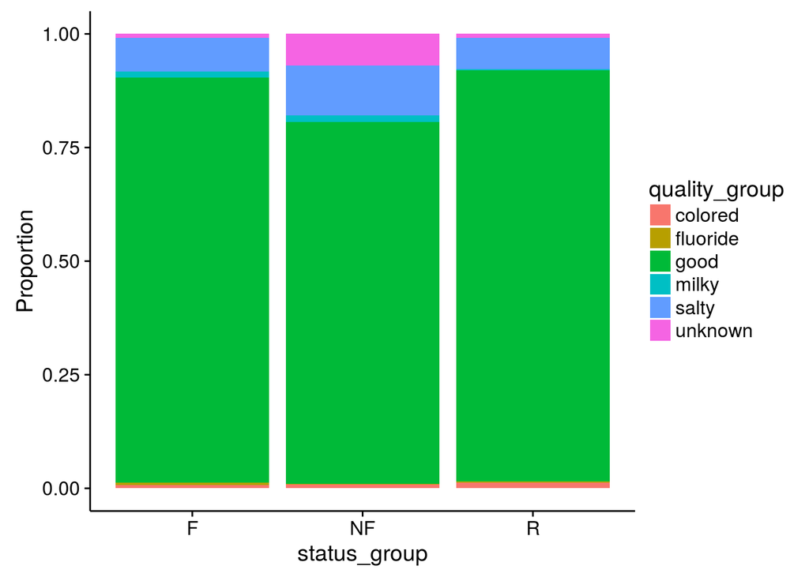

```r
ggplot(data=training) + geom_bar( aes(x=status_group,y=..count..,fill=quality_group),position="fill") + labs(y=("Proportion"))
```

Water Quality and Quality Type being unknown are big indicators of a non-functional pump.

```r
training %>% filter(water_quality=="unknown") %>% mutate(match=(water_quality==quality_group)) %>% summarise(percent=mean(match))
```

```
##   percent
## 1       1
```

These variables are actually always “unknown” in tandem.

#### Quantity

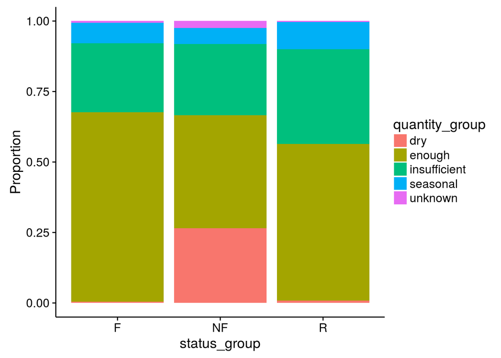

```r
ggplot(data=training) + geom_bar( aes(x=status_group,y=..count..,fill=quantity_group),position="fill") + labs(y=("Proportion"))
```

Quantity “dry” is almost a dead giveaway for a non-functioning pump. Again, “unknown” tends to be associated with a non functional pump.

#### Source

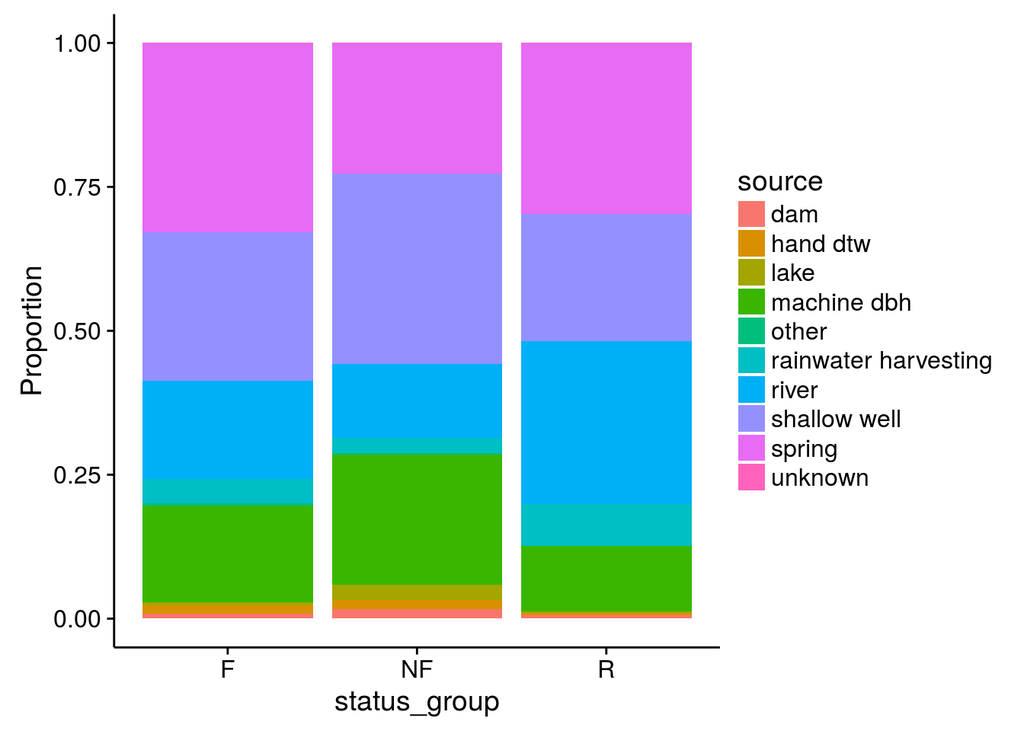

```r
ggplot(data=training) + geom_bar( aes(x=status_group,y=..count..,fill=source),position="fill") + labs(y=("Proportion"))
```

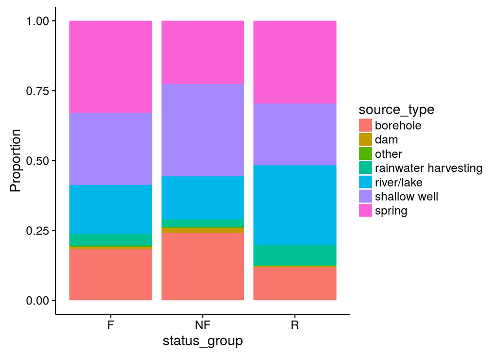

```r
ggplot(data=training) + geom_bar( aes(x=status_group,y=..count..,fill=source_type),position="fill") + labs(y=("Proportion"))
```

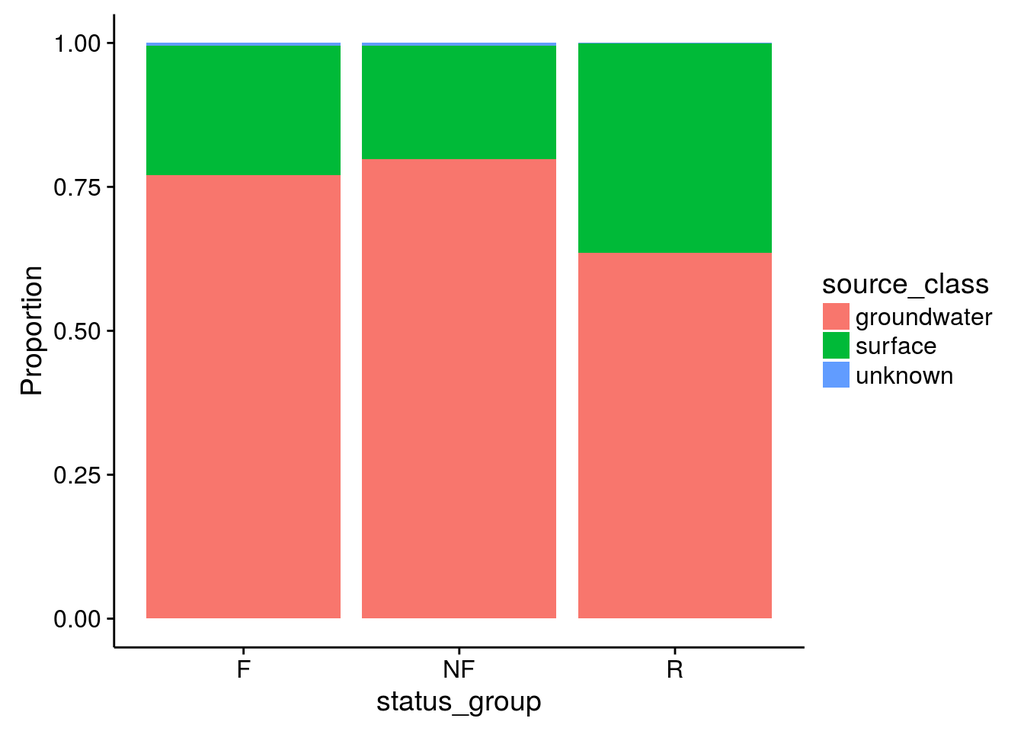

```r
ggplot(data=training) + geom_bar( aes(x=status_group,y=..count..,fill=source_class),position="fill") + labs(y=("Proportion"))
```

We actually see a good amount of variation in response according to these source variables. I expect these to be important in the model.

#### Watertype

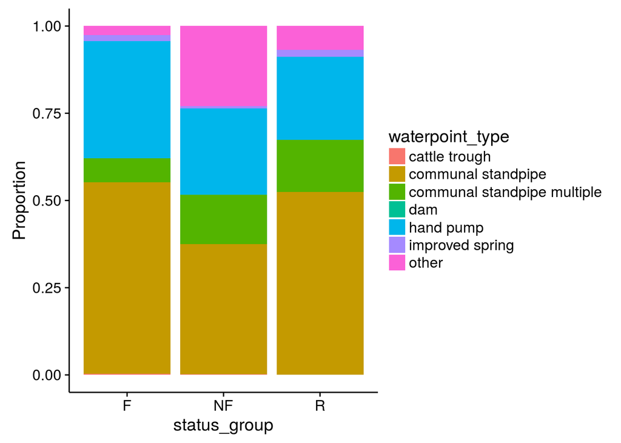

```r
ggplot(data=training) + geom_bar( aes(x=status_group,y=..count..,fill=waterpoint_type),position="fill") + labs(y=("Proportion"))
```

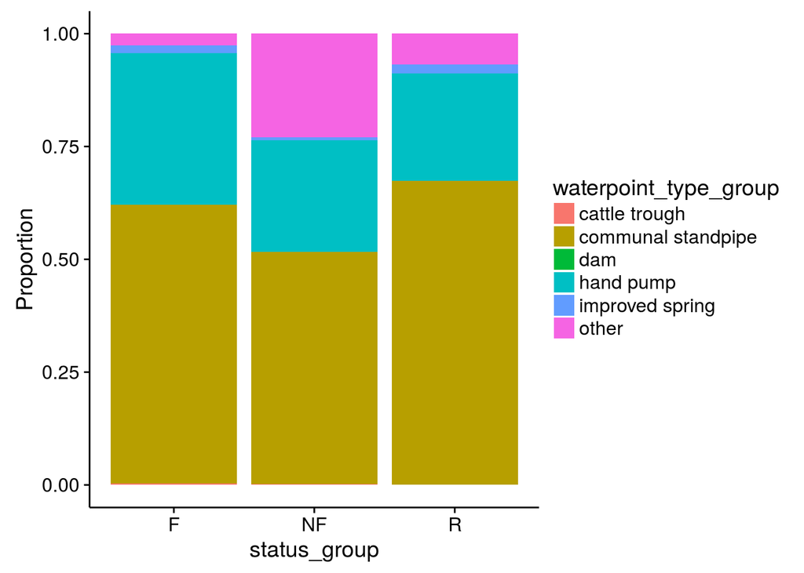

```r
ggplot(data=training) + geom_bar( aes(x=status_group,y=..count..,fill=waterpoint_type_group),position="fill") + labs(y=("Proportion"))
```

Hand pumps seem to fail the least (I imagine they have the fewest parts) and like we’ve seen in several other predictors, “other” tends to be associated with a broken pump.

# Final Thoughts

Based off this initial EDA, it appears like the categorical features are going to be more predictive than the numeric variables. Many of these variables have an “other” category that tends to correspond to a non-functioning pump. Most of the high cardinality features I’m just going to drop, but I want to try to collapse the installer variable and also the lga variable.